# Explore and plot by vector layer attributes

This episode continues our discussion of vector layer attributes and covers how to work with vector layer attributes in R. It covers how to identify and query layer attributes, as well as how to subset features by specific attribute values. Finally, we will learn how to plot a feature according to a set of attribute values.

**Objectives**

- Query attributes of a spatial object.
- Subset spatial objects using specific attribute values.
- Plot a vector feature, colored by unique attribute values.

**Keypoints**

- Spatial objects in `sf` are similar to standard data frames and can be manipulated using the same functions.
- Almost any feature of a plot can be customized using the various functions and options in the `ggplot2` package.

If you’re just opening up this project, you’ll have to load the packages and data used in previous episodes.

```r
# load packages
library(raster)
library(rgdal)
library(ggplot2)
library(dplyr)
library(sf)


# data loaded from earlier episode
# DSM data for Harvard Forest
dsm <- raster("data/raster/HARV_dsmCrop.tif")
dsm_df <- as.data.frame(dsm, xy = TRUE)

tower <- st_read("data/vector/HARVtower_UTM18N.shp")
roads <- st_read("data/vector/HARV_roads.shp")
aoi_boundary <- st_read("data/vector/HarClip_UTMZ18.shp")
```

```r
# look at point object
tower
```

```
## Simple feature collection with 1 feature and 14 fields
## Geometry type: POINT
## Dimension:     XY
## Bounding box:  xmin: 732183.2 ymin: 4713265 xmax: 732183.2 ymax: 4713265
## Projected CRS: WGS 84 / UTM zone 18N
##   Un_ID Domain DomainName       SiteName Type       Sub_Type     Lat      Long
## 1     A      1  Northeast Harvard Forest Core Advanced Tower 42.5369 -72.17266
##   Zone  Easting Northing                Ownership    County annotation
## 1   18 732183.2  4713265 Harvard University, LTER Worcester         C1
##                   geometry
## 1 POINT (732183.2 4713265)
```

We can use the `ncol` function to count the number of attributes associated with a spatial object too. Note that the geometry is just another column and counts towards the total.

We can also view the individual name of each attribute using the `names()` function.

We could also view just the first 6 rows of attribute values using the `head()` function to get a preview of the data:

```r
# look at number and names of attributes in line object
ncol(roads)
```

```
## [1] 16
```

```r
names(roads)
```

```
##  [1] "OBJECTID_1" "OBJECTID"   "TYPE"       "NOTES"      "MISCNOTES"
##  [6] "RULEID"     "MAPLABEL"   "SHAPE_LENG" "LABEL"      "BIKEHORSE"
## [11] "RESVEHICLE" "RECMAP"     "Shape_Le_1" "ResVehic_1" "BicyclesHo"
## [16] "geometry"
```

```r
head(roads)
```

```
## Simple feature collection with 6 features and 15 fields
## Geometry type: MULTILINESTRING
## Dimension:     XY
## Bounding box:  xmin: 730741.2 ymin: 4712685 xmax: 732232.3 ymax: 4713726
## Projected CRS: WGS 84 / UTM zone 18N
##   OBJECTID_1 OBJECTID       TYPE             NOTES MISCNOTES RULEID
## 1         14       48 woods road Locust Opening Rd      <NA>      5
## 2         40       91   footpath              <NA>      <NA>      6
## 3         41      106   footpath              <NA>      <NA>      6
## 4        211      279 stone wall              <NA>      <NA>      1
## 5        212      280 stone wall              <NA>      <NA>      1
## 6        213      281 stone wall              <NA>      <NA>      1
##            MAPLABEL SHAPE_LENG             LABEL BIKEHORSE RESVEHICLE RECMAP
## 1 Locust Opening Rd 1297.35706 Locust Opening Rd         Y         R1      Y
## 2              <NA>  146.29984              <NA>         Y         R1      Y
```

[output cut: 18 more lines]

# Explore Values within One Attribute

We can explore individual values stored within a particular attribute. Comparing attributes to a spreadsheet or a data frame, this is similar to exploring values in a column. We did this with the `gapminder` dataframe in [an earlier lesson](https://datacarpentry.org/r-intro-geospatial/05-data-subsetting/index.html). For spatial objects, we can use the same syntax: `objectName$attributeName`.

We can see the contents of the `TYPE` field of our lines feature:

```r
# view all records of single attribute
roads$TYPE
```

```
##  [1] "woods road" "footpath"   "footpath"   "stone wall" "stone wall"
##  [6] "stone wall" "stone wall" "stone wall" "stone wall" "boardwalk"
## [11] "woods road" "woods road" "woods road"
```

```r
unique(roads$TYPE)
```

```
## [1] "woods road" "footpath"   "stone wall" "boardwalk"
```

# Subset Features

We can use the `filter()` function from `dplyr` that we worked with in [an earlier lesson](https://datacarpentry.org/r-intro-geospatial/06-dplyr) to select a subset of features from a spatial object in R, just like with data frames.

For example, we might be interested only in features that are of `TYPE` “footpath”. Once we subset out this data, we can use it as input to other code so that code only operates on the footpath lines.

```r
footpath <- roads %>%
  filter(TYPE == "footpath")
```

Our subsetting operation reduces the `features` count to 2. This means that only two feature lines in our spatial object have the attribute `TYPE == footpath`. We can plot only the footpath lines:

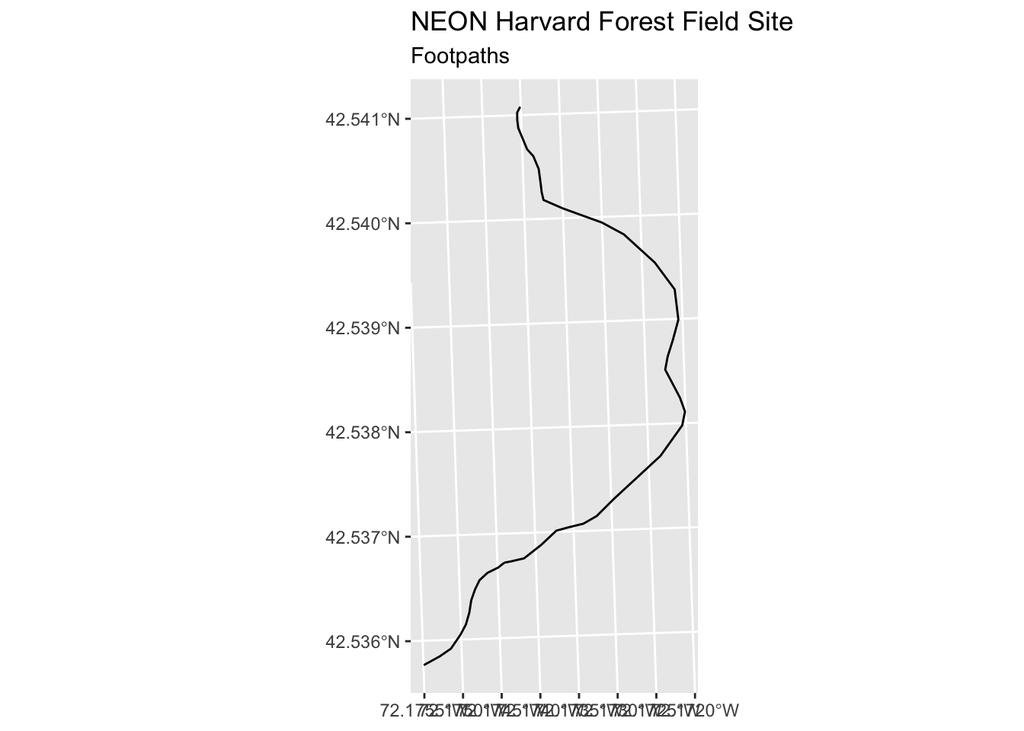

```r
# plot footpaths
# add title and subtitle
ggplot() +
  geom_sf(data = footpath) +
  ggtitle("NEON Harvard Forest Field Site", subtitle = "Footpaths") +
  coord_sf()
```

There are two features in our footpaths subset. Why does the plot look like there is only one feature? Let’s adjust the colors used in our plot. If we have 2 features in our vector object, we can plot each using a unique color by assigning a column name to the color aesthetic (`color =`). We use the syntax `aes(color = )` to do this. We can also alter the default line thickness by using the `size =` parameter, as the default value of 0.5 can be hard to see. Note that size is placed outside of the `aes()` function, as we are not connecting line thickness to a data variable.

```r
# color footpaths by object ID
ggplot() +
  geom_sf(data = footpath, aes(color = factor(OBJECTID)), size = 1.5) +
  labs(color = 'Footpath ID') +
  ggtitle("NEON Harvard Forest Field Site", subtitle = "Footpaths") +
  coord_sf()
```

[output not shown]

# Customize Plots

In the examples above, `ggplot()` automatically selected colors for each line based on a default color order. If we don’t like those default colors, we can create a vector of colors - one for each feature. To create this vector we can use the following syntax:

`c("color_one", "color_two", "color_three")[object$factor]`

Note in the above example we have

1. a vector of colors - one for each factor value (unique attribute value)
2. the attribute itself (`[object$factor]`) of class factor.

First we will check how many unique levels our factor has:

```r
# check number of unique types
unique(roads$TYPE)
```

```
## [1] "woods road" "footpath"   "stone wall" "boardwalk"
```

```r
# set unique color vector
road_colors <- c("blue", "green", "navy", "purple")
```

We can tell `ggplot` to use these colors when we plot the data.

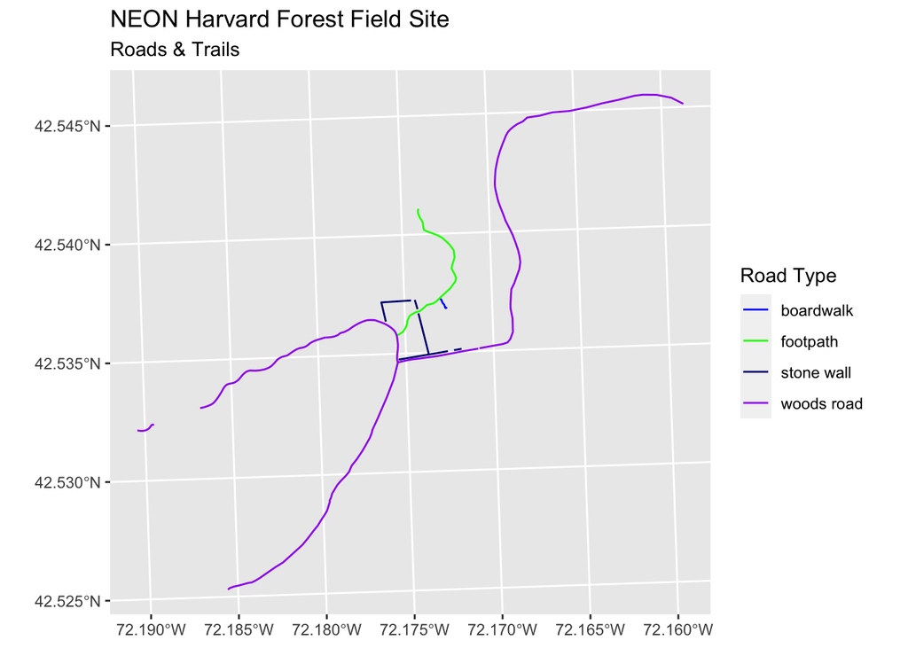

```r
# plot road types using custom colors
ggplot() +
  geom_sf(data = roads, aes(color = TYPE)) +
  scale_color_manual(values = road_colors) +
  labs(color = 'Road Type') +
  ggtitle("NEON Harvard Forest Field Site", subtitle = "Roads & Trails") +
  coord_sf()
```

The material has been adapted from The Carpentries [Introduction to Geospatial Raster and Vector Data with R](https://datacarpentry.org/r-raster-vector-geospatial/01-raster-structure/index.html) lesson licensed under [CC-BY 4.0](https://creativecommons.org/licenses/by/4.0/)